# EXP5

```python
print("URK23CS1246")
import math
import numpy as np
import pandas as pd
import matplotlib.pyplot as plt
from scipy import stats
csv_path = "environment_5.csv"
df = pd.read_csv(csv_path)
aqi = df['Air Quality Index'].dropna().astype(float)
```

```
URK23CS1246
```

```python
print("URK23CS1246")
# Q1. Calculate the central tendency measures for a ‘Air Quality Index’ column
print("Mean:",
      aqi.mean())
print("Median:", aqi.median())
print("Mode:", aqi.mode().tolist())
```

```
URK23CS1246
Mean: 61.467415
Median: 60.73
Mode: [55.36]
```

Inference: The mean (61.47) and median (60.73) of the Air Quality Index are very close, indicating that the data is approximately symmetric with no extreme outliers significantly affecting the average. The mode (55.36) shows that this value occurs most frequently, suggesting that most air quality readings cluster around the moderate AQI range

```python
print("URK23CS1246")
# Q2. Calculate the variability measures for a ‘Air Quality Index’ column
print("Variance:", aqi.var())
print("Standard Deviation:", aqi.std())
print("Range:", aqi.max() - aqi.min())
print("Min:", aqi.min(), " Max:", aqi.max())
```

```
URK23CS1246
Variance: 354.23984168861926
Standard Deviation: 18.821260363977203
Range: 281.89
Min: 11.38  Max: 293.27
```

Inference: The variance (354.24) and standard deviation (18.82) indicate a moderate spread of AQI values around the mean, meaning air quality levels vary noticeably across observations. The range (281.89) between the minimum (11.38) and maximum (293.27) shows that the dataset includes both very clean and highly polluted air conditions, reflecting significant variability in air quality.

```
URK23CS1246
```

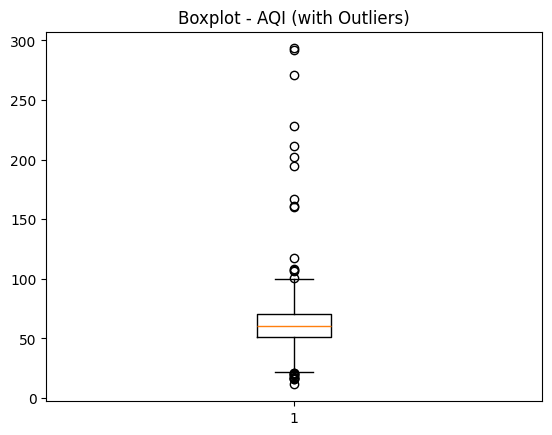

```python
print("URK23CS1246")
# Q3. Detect the outliers in a ‘Air Quality Index’ column with boxplot
plt.boxplot(aqi)
plt.title("Boxplot - AQI (with Outliers)")
plt.show()
```

Inference: The boxplot of the Air Quality Index (AQI) shows that most values are concentrated between roughly 45 and 70, indicating that the majority of air quality readings fall in the moderate range. However, there are several high outliers above 100 and up to nearly 300, which suggest occasional periods of poor or very poor air quality.

```python
print("URK23CS1246")
# Q4. Calculate IQR & z-score for a ‘Air Quality Index’ column
Q1, Q3 = aqi.quantile([0.25, 0.75])
IQR = Q3 - Q1
z_scores = stats.zscore(aqi)
print("IQR:", IQR)
print("First 5 Z-scores:", z_scores[:5])
```

```
URK23CS1246
IQR: 19.647499999999994
First 5 Z-scores: [ 0.31794264 -0.18799483  0.43858109  1.1363709  -0.26452319]
```

Inference: The IQR (19.65) shows a moderate spread in AQI values around the middle 50% of data. The Z-scores are mostly close to zero, indicating that most AQI readings are near the mean, with no extreme outliers among the first few observations.

```
URK23CS1246
New IQR after removing outliers: 19.375000000000007
```

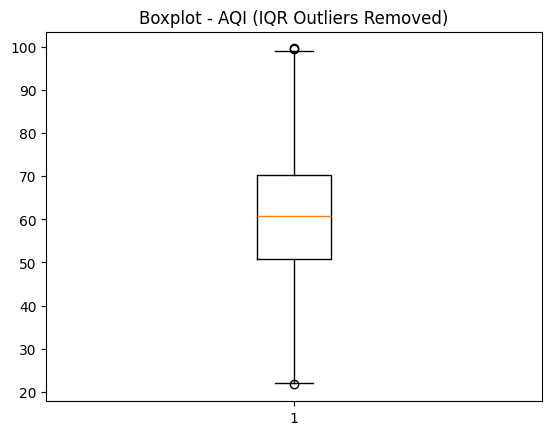

```python
print("URK23CS1246")
# Q5. Remove outliers using IQR and recalc IQR + boxplot
df_iqr = df.copy()
Q1 = df['Air Quality Index'].quantile(0.25)
Q3 = df['Air Quality Index'].quantile(0.75)
IQR = Q3 - Q1
lower, upper = Q1 - 1.5*IQR, Q3 + 1.5*IQR
df_iqr = df_iqr[(df_iqr['Air Quality Index'] >= lower) & (df_iqr['Air Quality Index'] <= upper)]
new_IQR = df_iqr['Air Quality Index'].quantile(0.75) - df_iqr['Air Quality Index'].quantile(0.25)
print("New IQR after removing outliers:", new_IQR)
plt.boxplot(df_iqr['Air Quality Index'])
plt.title("Boxplot - AQI (IQR Outliers Removed)")
plt.show()
```

Inference: After removing outliers using the IQR method, the new IQR (19.38) indicates that the data is now more compact and consistent. The boxplot shows a balanced distribution of AQI values without extreme variations, meaning most readings now represent typical air quality levels.

```
URK23CS1246
Shape after removing Z-score outliers: (1990, 5)
```

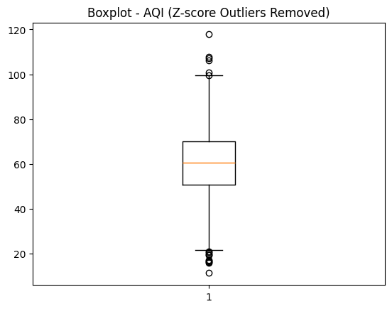

```python
print("URK23CS1246")
# Q6. Remove outliers using z-score and recalc + boxplot\
df_z = df.copy()
df_z = df_z[(np.abs(stats.zscore(df_z['Air Quality Index'])) < 3)]
print("Shape after removing Z-score outliers:", df_z.shape)
plt.boxplot(df_z['Air Quality Index'])
plt.title("Boxplot - AQI (Z-score Outliers Removed)")
plt.show()
```

Inference: After removing outliers using the Z-score method, the AQI values appear more evenly distributed around the median. The boxplot shows fewer extreme points, indicating that most abnormal values have been filtered out, resulting in a cleaner and more reliable dataset for analysis.

```python
print("URK23CS1246")
# Q7. Display the correlation matrix
print(df.corr(numeric_only=True))
```

```
URK23CS1246
                       Air Quality Index  Daily Commute Traffic  \
Air Quality Index               1.000000               0.014191
Daily Commute Traffic           0.014191               1.000000
Temperature (C)                -0.040526               0.045461
Rainfall (mm)                   0.029118               0.025180

                       Temperature (C)  Rainfall (mm)
Air Quality Index            -0.040526       0.029118
Daily Commute Traffic         0.045461       0.025180
Temperature (C)               1.000000       0.006199
Rainfall (mm)                 0.006199       1.000000
```

Inference: The correlation values are all close to zero, indicating very weak or no linear relationship between the variables. This means that factors like temperature, rainfall, and daily commute traffic have minimal direct impact on the Air Quality Index in this dataset.

```
URK23CS1246
```

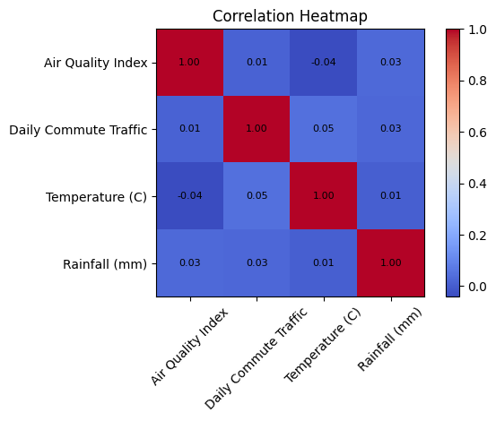

```python
print("URK23CS1246")
# Q8. Plot the heatmap using correlation
corr = df.corr(numeric_only=True)
plt.imshow(corr, cmap="coolwarm", interpolation="nearest")
plt.colorbar()
plt.xticks(range(len(corr.columns)), corr.columns, rotation=45)
plt.yticks(range(len(corr.columns)), corr.columns)
plt.title("Correlation Heatmap")

# ---- Add numeric values on the heatmap ----
for i in range(len(corr.columns)):
    for j in range(len(corr.columns)):
        value = corr.iloc[i, j]
        plt.text(j, i, f"{value:.2f}", ha='center', va='center', color='black', fontsize=8)

plt.tight_layout()
plt.show()
```

Inference: The heatmap shows that all correlation values are very close to zero, meaning there is no strong relationship between any pair of variables. Thus, Air Quality Index, Traffic, Temperature, and Rainfall behave mostly independently, with none having a significant effect on the others.

```python
print("URK23CS1246")
# Q9. Calculate sample mean for AQI with n=500, n=1500
sample_500 = aqi.sample(n=500, random_state=42).mean()
sample_1500 = aqi.sample(n=1500, random_state=42).mean()
print("Population Mean:", aqi.mean())
print("Sample Mean (n=500):", sample_500)
print("Sample Mean (n=1500):", sample_1500, "\n")
```

```
URK23CS1246
Population Mean: 61.467415
Sample Mean (n=500): 62.97821999999999
Sample Mean (n=1500): 61.68323333333333
```

Inference: Both sample means (62.98 for n=500 and 61.68 for n=1500) are very close to the population mean (61.47), showing that larger samples give more accurate estimates of the population mean.

```python
print("URK23CS1246")
# Q10. Confidence Interval (n=500, 95%)
sample = aqi.sample(n=500, random_state=42)
mean = sample.mean()
std = sample.std(ddof=1)
se = std / math.sqrt(500)
ci_95 = stats.norm.interval(0.95, loc=mean, scale=se)
print("Sample Mean:", mean)
print("95% CI:", ci_95)
print("Population Mean lies in CI?", ci_95[0] <= aqi.mean() <= ci_95[1], "\n")
```

```
URK23CS1246
Sample Mean: 62.97821999999999
95% CI: (np.float64(61.20085687493712), np.float64(64.75558312506287))
Population Mean lies in CI? True
```

Inference: The 95% confidence interval (61.20 to 64.76) includes the population mean (61.47), indicating that the sample mean is a reliable estimate of the population mean and the sampling process is accurate.

```python
print("URK23CS1246")
# Q11. Confidence Interval (n=500, 99%)
print("Q11: CI 99% for n=500")
ci_99 = stats.norm.interval(0.99, loc=mean, scale=se)
print("99% CI:", ci_99)
print("Population Mean lies in CI?", ci_99[0] <= aqi.mean() <= ci_99[1])
```

```
URK23CS1246
Q11: CI 99% for n=500
99% CI: (np.float64(60.642368904420515), np.float64(65.31407109557948))
Population Mean lies in CI? True
```

Inference: The 99% confidence interval (60.64 to 65.31) also contains the population mean (61.47), showing that with higher confidence, the true mean lies within this wider range. Increasing confidence level slightly widens the interval, but the estimate remains accurate.

```
URK23CS1246
```

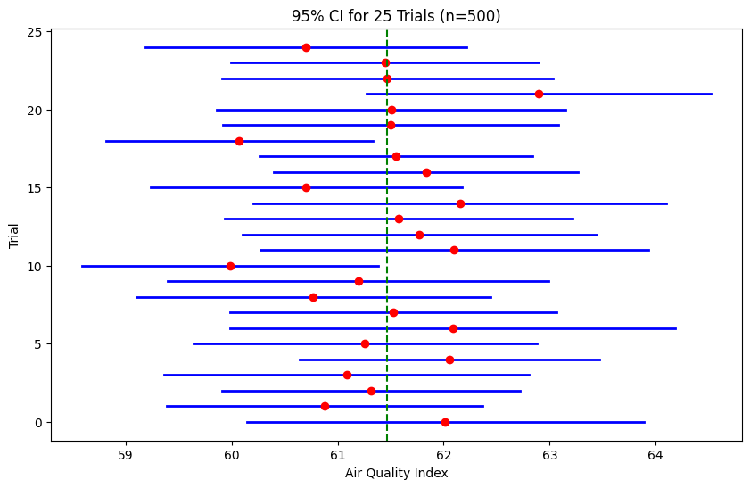

```python
print("URK23CS1246")
# Q12. Plot CI for 25 Trials (n=500, CI=95%)
plt.figure(figsize=(10,6))
pop_mean = aqi.mean()
for i in range(25):
    s = aqi.sample(n=500, random_state=i)
    m, sd = s.mean(), s.std(ddof=1)
    se = sd / math.sqrt(500)
    ci = stats.norm.interval(0.95, loc=m, scale=se)
    plt.plot([ci[0], ci[1]], [i, i], 'b-', lw=2)
    plt.plot(m, i, 'ro')
plt.axvline(pop_mean, color='g', linestyle='--')
plt.title("95% CI for 25 Trials (n=500)")
plt.xlabel("Air Quality Index")
plt.ylabel("Trial")
plt.show()
```

The plot shows 25 confidence intervals (CIs) for samples of size 500. Most of the blue intervals include the green dashed line (population mean), indicating that about 95% of the intervals contain the true mean, which is consistent with the 95% confidence level. Only a few intervals may miss the population mean, demonstrating the concept of sampling variability — even with the same sample size, sample means and CIs fluctuate slightly

```python
print("URK23CS1246")
# Q13. Correlation Coefficient (Pearson) AQI & Daily Commute Traffic
pearson_corr, _ = stats.pearsonr(df['Air Quality Index'], df['Daily Commute Traffic'])
print("Pearson Correlation:", pearson_corr, "\n")
```

```
URK23CS1246
Pearson Correlation: 0.014191334901063741
```

Inference: The Pearson correlation coefficient (≈ 0.014) shows a very weak positive relationship between Air Quality Index and Daily Commute Traffic. This means traffic levels have almost no linear impact on air quality in this dataset.

```python
print("URK23CS1246")
# Q14. Correlation Coefficient (Spearman) AQI & Temperature (C)
spearman_corr, _ = stats.spearmanr(df['Air Quality Index'], df['Temperature (C)'])
print("Spearman Correlation:", spearman_corr, "\n")
```

```
URK23CS1246
Spearman Correlation: -0.024141214630486303
```

Inference: The Spearman correlation (≈ -0.024) indicates a very weak negative relationship between Air Quality Index and Temperature. This suggests that as temperature changes, the air quality shows almost no monotonic trend, meaning temperature has little to no effect on AQI in this dataset.

```python
print("URK23CS1246")
# Q15. Hypothesis Testing (Z-test)
mu, sigma, n, sample_mean, alpha, z_crit = 75, 10, 40, 78, 0.05, 1.645
z = (sample_mean - mu) / (sigma / math.sqrt(n))
print("Z-score:", z)
if z > z_crit:
    print("Reject Null Hypothesis → Claim supported (mean improved)\n")
else:
    print("Fail to Reject Null Hypothesis → Claim not supported\n")
```

```
URK23CS1246
Z-score: 1.8973665961010278
Reject Null Hypothesis → Claim supported (mean improved)
```

Inference: The calculated Z-score = 1.90, which is greater than the critical value (1.645) at a 5% significance level (α = 0.05). Hence, we reject the null hypothesis, indicating that the sample mean (78) is significantly higher than the population mean (75).